# Count / Rate Outcomes in ForestSearch

GRF Subgroup Identification, Per-Subgroup Estimation, and Biomarker Profiling for Poisson Data

Author

Larry F. Leon

Published

March 27, 2026

# 1 Introduction

ForestSearch v0.2.0 extends subgroup identification beyond survival and binary outcomes to **count / rate data** via Poisson, quasi-Poisson, and negative-binomial GLMs. This document exercises the three new user-facing functions on synthetic clinical trial data with a known treatment-effect subgroup:

| Function | Purpose |
| --- | --- |
| `grf.subg.harm.glm()` | GRF-based subgroup identification for GLM outcomes |
| `create_glm_row()` | Per-subgroup GLM effect estimation (one-row summary) |
| `glm_effect_profile()` | Delta-method treatment-effect profile across a continuous biomarker |

The DGM plants a **harm subgroup** (`v1 = 1`) where treatment *increases* the event rate (IRR > 1), while the complement benefits from treatment (IRR < 1). The overall ITT effect is near null by design, making subgroup identification the analytic goal.

# 2 Setup

```r
library(forestsearch)
library(ggplot2)
library(patchwork)
library(gt)
```

```r
timings <- list()
t_vignette_start <- proc.time()
```

# 3 Synthetic Data

```r
set.seed(42)
n <- 800

# -- Covariates ---------------------------------------------------------------
df <- data.frame(
  id          = seq_len(n),
  treat       = rbinom(n, 1, 0.5),
  v1          = as.factor(rbinom(n, 1, 0.35)),
  v2          = as.factor(rbinom(n, 1, 0.50)),
  v3          = as.factor(rbinom(n, 1, 0.45)),
  age         = round(rnorm(n, 60, 12)),
  biomarker   = round(runif(n, 0.5, 5.0), 2),
  person_time = round(runif(n, 0.5, 3.0), 2)
)

# -- Outcome: Poisson with heterogeneous treatment effect ---------------------
# v1 = 1 (harm):       log(IRR) = +0.7  (IRR ~ 2.0, treatment harmful)
# v1 = 0 (complement): log(IRR) = -0.4  (IRR ~ 0.67, treatment beneficial)
# Continuous biomarker adds a smooth interaction on top

log_rate <- with(df, {
  -1.2 +                                # baseline log-rate
    0.7  * treat * (v1 == 1) +           # harm subgroup effect
    -0.4 * treat * (v1 == 0) +           # complement benefit
    0.15 * treat * (biomarker - 2.5) +   # continuous interaction
    0.02 * (age - 60) +                  # age effect on rate
    log(person_time)                     # offset (exposure)
})

df$events <- rpois(n, lambda = exp(log_rate))
```

```r
cat("=== Data Summary ===\n")
```

```
#> === Data Summary ===
```

```r
cat("N:", n, "\n")
```

```
#> N: 800
```

```r
cat("Events: mean =", round(mean(df$events), 2),
    ", range = [", min(df$events), ",", max(df$events), "]\n")
```

```
#> Events: mean = 0.58 , range = [ 0 , 6 ]
```

```r
cat("Zero counts:", sum(df$events == 0),
    sprintf("(%.1f%%)\n", 100 * mean(df$events == 0)))
```

```
#> Zero counts: 462 (57.8%)
```

```r
cat("Person-time: mean =", round(mean(df$person_time), 2), "years\n")
```

```
#> Person-time: mean = 1.71 years
```

```r
cat("\nPer-arm event rates:\n")
```

```
#>
#> Per-arm event rates:
```

```r
for (arm in 0:1) {
  idx <- df$treat == arm
  rate <- sum(df$events[idx]) / sum(df$person_time[idx])
  cat(sprintf("  treat = %d: events = %d, PT = %.1f, rate = %.3f/yr\n",
              arm, sum(df$events[idx]), sum(df$person_time[idx]), rate))
}
```

```
#>   treat = 0: events = 225, PT = 718.5, rate = 0.313/yr
#>   treat = 1: events = 239, PT = 649.8, rate = 0.368/yr
```

```r
truth <- data.frame(
  Subgroup = c("v1 = 1 (harm)", "v1 = 0 (complement)", "Overall"),
  `True log-IRR` = c(0.7, -0.4, NA),
  `True IRR` = c(exp(0.7), exp(-0.4), NA),
  check.names = FALSE
)

# Compute observed overall IRR
fit_overall <- glm(events ~ treat + offset(log(person_time)),
                   family = poisson, data = df)
truth$`True IRR`[3] <- exp(coef(fit_overall)["treat"])
truth$`True log-IRR`[3] <- coef(fit_overall)["treat"]

gt(truth) |>
  tab_header(title = "DGM Treatment Effects") |>
  fmt_number(columns = c("True log-IRR", "True IRR"), decimals = 3)
```

True treatment effects by subgroup

DGM Treatment Effects

| Subgroup | True log-IRR | True IRR |
| --- | --- | --- |
| v1 = 1 (harm) | 0.700 | 2.014 |
| v1 = 0 (complement) | −0.400 | 0.670 |
| Overall | 0.161 | 1.174 |

# 4 GRF Subgroup Identification

`grf.subg.harm.glm()` uses `grf::causal_forest()` for candidate variable screening (with a variance-stabilising $\log(Y + 0.5)$ transformation for count data), followed by policy-tree enumeration and GLM-based effect estimation.

## 4.1 Standard Poisson

```r
t0 <- proc.time()[3]

grf_pois <- grf.subg.harm.glm(
  data                = df,
  confounders.name    = c("v1", "v2", "v3", "age"),
  outcome.name        = "events",
  treat.name          = "treat",
  id.name             = "id",
  outcome_type        = "count",
  effect_measure      = "log_IRR",
  offset.name         = "person_time",
  overdispersion      = "none",
  grf_count_transform = "log",
  n.min               = 60,
  dmin.grf            = 0,
  maxdepth            = 2,
  RCT                 = TRUE,
  conf.level          = 0.95,
  seedit              = 8316951,
  verbose             = TRUE
)

timings$grf_poisson <- proc.time()[3] - t0
```

```r
cat("\n=== GRF Subgroup Identification (Poisson) ===\n")
```

```
#>
#> === GRF Subgroup Identification (Poisson) ===
```

```r
cat("Subgroup found:", !is.null(grf_pois$sg.harm.id), "\n")
```

```
#> Subgroup found: TRUE
```

```r
if (!is.null(grf_pois$sg.harm.id)) {
  cat("Definition:", paste(grf_pois$sg.harm.id, collapse = " & "), "\n")
  n_harm <- sum(grf_pois$data$treat.recommend == 0)
  cat(sprintf("Size: n(H) = %d (%.1f%%)\n", n_harm, 100 * n_harm / n))
}
```

```
#> Definition: v2 <= 1 & v1 <= 1 & age <= 53
#> Size: n(H) = 389 (48.6%)
```

```r
cat("\nGRF variable importance:\n")
```

```
#>
#> GRF variable importance:
```

```r
vi <- sort(grf_pois$grf_varimp, decreasing = TRUE)
for (i in seq_along(vi)) {
  cat(sprintf("  %s: %.4f\n", names(vi)[i], vi[i]))
}
```

```
#>   age: 0.4201
#>   v1: 0.4125
#>   v2: 0.0897
#>   v3: 0.0777
```

```r
cat("\nGRF Y transform:", grf_pois$grf_y_transform, "\n")
```

```
#>
#> GRF Y transform: log(Y + 0.5)
```

## 4.2 Quasi-Poisson

```r
t0 <- proc.time()[3]

grf_quasi <- grf.subg.harm.glm(
  data                = df,
  confounders.name    = c("v1", "v2", "v3", "age"),
  outcome.name        = "events",
  treat.name          = "treat",
  id.name             = "id",
  outcome_type        = "count",
  effect_measure      = "log_IRR",
  offset.name         = "person_time",
  overdispersion      = "quasi",
  grf_count_transform = "log",
  n.min               = 60,
  conf.level          = 0.95,
  seedit              = 8316951,
  verbose             = TRUE
)

timings$grf_quasi <- proc.time()[3] - t0

cat("Quasi-Poisson SG:", paste(grf_quasi$sg.harm.id, collapse = " & "), "\n")
```

```
#> Quasi-Poisson SG: v2 <= 1 & v1 <= 1 & age <= 53
```

# 5 Per-Subgroup Estimation with `create_glm_row()`

`create_glm_row()` fits a GLM within a pre-defined subgroup and returns a one-row data frame with point estimate, CI, sample size, and event counts. This is the building block used internally by `grf.subg.harm.glm()`.

```r
# Define subgroups from the GRF result
sg_indicator <- grf_pois$data$treat.recommend
df_harm <- df[sg_indicator == 0, ]
df_comp <- df[sg_indicator == 1, ]

# --- Poisson (model-based SEs) ---
row_harm_pois <- create_glm_row(
  df             = df_harm,
  outcome.name   = "events",
  treat.name     = "treat",
  effect_measure = "log_IRR",
  offset.name    = "person_time",
  overdispersion = "none",
  conf.level     = 0.95
)

row_comp_pois <- create_glm_row(
  df             = df_comp,
  outcome.name   = "events",
  treat.name     = "treat",
  effect_measure = "log_IRR",
  offset.name    = "person_time",
  overdispersion = "none",
  conf.level     = 0.95
)

row_itt_pois <- create_glm_row(
  df             = df,
  outcome.name   = "events",
  treat.name     = "treat",
  effect_measure = "log_IRR",
  offset.name    = "person_time",
  overdispersion = "none",
  conf.level     = 0.95
)

# --- Quasi-Poisson (dispersion-corrected SEs) ---
row_harm_quasi <- create_glm_row(
  df             = df_harm,
  outcome.name   = "events",
  treat.name     = "treat",
  effect_measure = "log_IRR",
  offset.name    = "person_time",
  overdispersion = "quasi",
  conf.level     = 0.95
)

row_comp_quasi <- create_glm_row(
  df             = df_comp,
  outcome.name   = "events",
  treat.name     = "treat",
  effect_measure = "log_IRR",
  offset.name    = "person_time",
  overdispersion = "quasi",
  conf.level     = 0.95
)
```

```r
est_table <- data.frame(
  Subgroup = c("Harm (H)", "Complement (Hc)", "ITT"),
  N = c(row_harm_pois$N, row_comp_pois$N, row_itt_pois$N),
  Events_T = c(row_harm_pois$events_treat, row_comp_pois$events_treat,
               row_itt_pois$events_treat),
  Events_C = c(row_harm_pois$events_control, row_comp_pois$events_control,
               row_itt_pois$events_control),
  log_IRR_pois = c(row_harm_pois$est, row_comp_pois$est, row_itt_pois$est),
  SE_pois = c(row_harm_pois$se, row_comp_pois$se, row_itt_pois$se),
  log_IRR_quasi = c(row_harm_quasi$est, row_comp_quasi$est, NA),
  SE_quasi = c(row_harm_quasi$se, row_comp_quasi$se, NA),
  True_logIRR = c(0.7, -0.4, truth$`True log-IRR`[3]),
  stringsAsFactors = FALSE
)

gt(est_table) |>
  tab_header(
    title = "Subgroup Effect Estimates",
    subtitle = "Poisson vs quasi-Poisson standard errors"
  ) |>
  fmt_number(columns = c(log_IRR_pois, SE_pois, log_IRR_quasi, SE_quasi,
                          True_logIRR), decimals = 3) |>
  cols_label(
    Subgroup = "Subgroup",
    N = "N",
    Events_T = "Events (Rx)",
    Events_C = "Events (Ctrl)",
    log_IRR_pois = "log-IRR",
    SE_pois = "SE (Pois)",
    log_IRR_quasi = "log-IRR",
    SE_quasi = "SE (Quasi)",
    True_logIRR = "True"
  ) |>
  tab_spanner(label = "Poisson", columns = c(log_IRR_pois, SE_pois)) |>
  tab_spanner(label = "Quasi-Poisson", columns = c(log_IRR_quasi, SE_quasi)) |>
  tab_source_note("True log-IRR: H = +0.70, Hc = -0.40")
```

Per-subgroup log-IRR estimates: Poisson vs quasi-Poisson

Subgroup Effect Estimates

Poisson vs quasi-Poisson standard errors

[output not shown]

True log-IRR: H = +0.70, Hc = -0.40

# 6 Biomarker Treatment-Effect Profile

`glm_effect_profile()` estimates the treatment effect as a smooth function of a continuous biomarker using natural cubic splines with delta-method CIs. This is the GLM analog of `cox_cs_fit()`.

## 6.1 Poisson Profile

```r
t0 <- proc.time()[3]

prof_pois <- glm_effect_profile(
  df             = df,
  outcome.name   = "events",
  treat.name     = "treat",
  z.name         = "biomarker",
  effect_measure = "log_IRR",
  offset.name    = "person_time",
  overdispersion = "none",
  spline_df      = 3,
  z_by           = 0.05,
  z_quantile     = 0.95,
  alpha          = 0.05,
  verbose        = TRUE
)

timings$profile_poisson <- proc.time()[3] - t0

print(prof_pois)
```

```
#> GLM Effect Profile (poisson(log) / log_IRR)
#>   Profile points: 86
#>   Effect range: -0.264 to 0.496
#>   CI level: 95 %
```

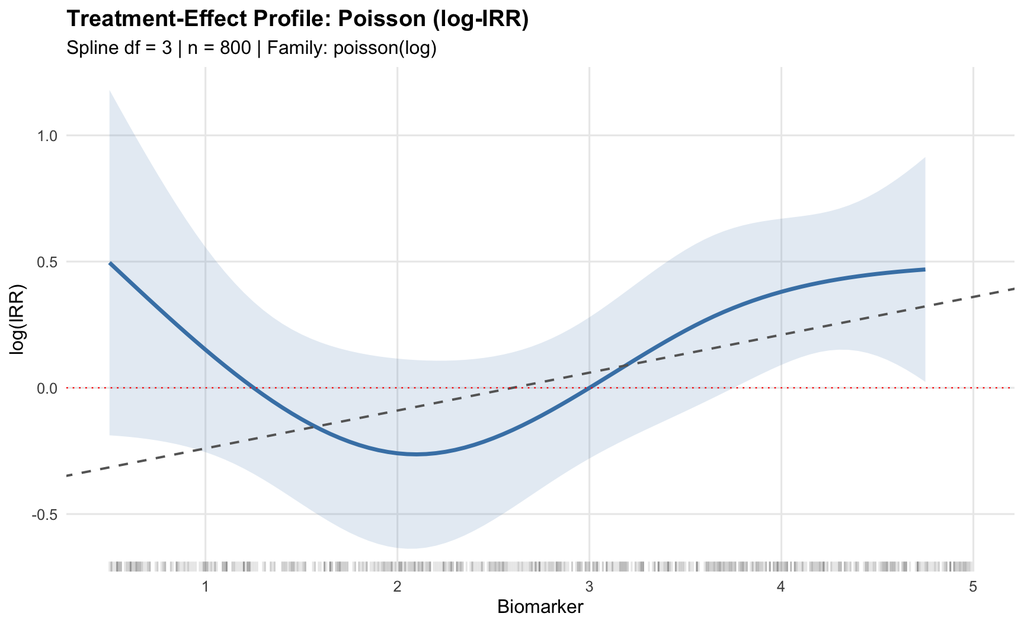

Poisson log-IRR profile with 95 percent delta-method CIs. Dashed grey line: true linear interaction slope from the DGM.

```r
df_prof <- data.frame(
  biomarker = prof_pois$z_profile,
  est       = prof_pois$est,
  lower     = prof_pois$lower,
  upper     = prof_pois$upper
)

# True interaction: 0.15 * (biomarker - 2.5) + weighted average of
# subgroup effects
true_slope <- 0.15
true_intercept <- 0.7 * 0.35 + (-0.4) * 0.65  # prevalence-weighted

ggplot(df_prof, aes(x = biomarker, y = est)) +
  geom_ribbon(aes(ymin = lower, ymax = upper), alpha = 0.15, fill = "steelblue") +
  geom_line(linewidth = 1.2, color = "steelblue") +
  geom_abline(intercept = true_intercept - true_slope * 2.5,
              slope = true_slope,
              linetype = "dashed", color = "grey40", linewidth = 0.7) +
  geom_hline(yintercept = 0, linetype = "dotted", color = "red", linewidth = 0.4) +
  geom_rug(data = df, aes(x = biomarker, y = NULL),
           alpha = 0.1, sides = "b", length = unit(0.02, "npc")) +
  labs(x = "Biomarker", y = "log(IRR)",
       title = "Treatment-Effect Profile: Poisson (log-IRR)",
       subtitle = sprintf("Spline df = 3 | n = %d | Family: %s",
                           nrow(df), prof_pois$family_used)) +
  theme_minimal(base_size = 12) +
  theme(panel.grid.minor = element_blank(),
        plot.title = element_text(face = "bold"))
```

## 6.2 Quasi-Poisson Profile

```r
prof_quasi <- glm_effect_profile(
  df             = df,
  outcome.name   = "events",
  treat.name     = "treat",
  z.name         = "biomarker",
  effect_measure = "log_IRR",
  offset.name    = "person_time",
  overdispersion = "quasi",
  spline_df      = 3,
  z_by           = 0.05,
  z_quantile     = 0.95,
  alpha          = 0.05,
  verbose        = TRUE
)

print(prof_quasi)
```

```
#> GLM Effect Profile (quasipoisson(log) / log_IRR)
#>   Profile points: 86
#>   Effect range: -0.264 to 0.496
#>   Dispersion: 1.0827
#>   CI level: 95 %
```

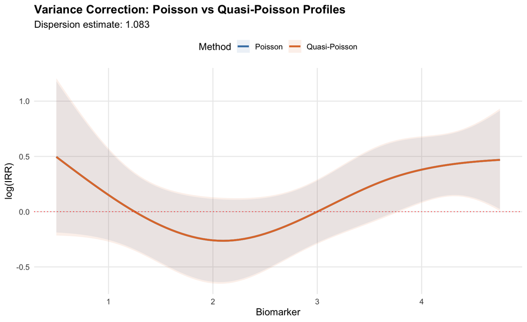

Poisson vs quasi-Poisson: point estimates are identical; quasi-Poisson CIs are wider when dispersion > 1.

```r
df_comp <- rbind(
  data.frame(biomarker = prof_pois$z_profile, est = prof_pois$est,
             lower = prof_pois$lower, upper = prof_pois$upper,
             Method = "Poisson"),
  data.frame(biomarker = prof_quasi$z_profile, est = prof_quasi$est,
             lower = prof_quasi$lower, upper = prof_quasi$upper,
             Method = "Quasi-Poisson")
)

ggplot(df_comp, aes(x = biomarker, y = est, colour = Method, fill = Method)) +
  geom_ribbon(aes(ymin = lower, ymax = upper), alpha = 0.10, colour = NA) +
  geom_line(linewidth = 1.1) +
  geom_hline(yintercept = 0, linetype = "dotted", color = "red", linewidth = 0.4) +
  scale_colour_manual(values = c("Poisson" = "steelblue",
                                  "Quasi-Poisson" = "#E07B39")) +
  scale_fill_manual(values = c("Poisson" = "steelblue",
                                "Quasi-Poisson" = "#E07B39")) +
  labs(x = "Biomarker", y = "log(IRR)",
       title = "Variance Correction: Poisson vs Quasi-Poisson Profiles",
       subtitle = sprintf("Dispersion estimate: %.3f", prof_quasi$dispersion)) +
  theme_minimal(base_size = 12) +
  theme(legend.position = "top", panel.grid.minor = element_blank(),
        plot.title = element_text(face = "bold"))
```

# 7 Negative Binomial Profile

For data with substantial overdispersion, `glm_effect_profile()` supports negative-binomial regression via `MASS::glm.nb()`.

```r
prof_nb <- glm_effect_profile(
  df             = df,
  outcome.name   = "events",
  treat.name     = "treat",
  z.name         = "biomarker",
  effect_measure = "log_IRR",
  offset.name    = "person_time",
  overdispersion = "negbin",
  spline_df      = 3,
  z_by           = 0.05,
  z_quantile     = 0.95,
  alpha          = 0.05,
  verbose        = TRUE
)

print(prof_nb)
```

```
#> GLM Effect Profile (negative_binomial / log_IRR)
#>   Profile points: 86
#>   Effect range: -0.266 to 0.501
#>   Dispersion: 0.0766
#>   CI level: 95 %
```

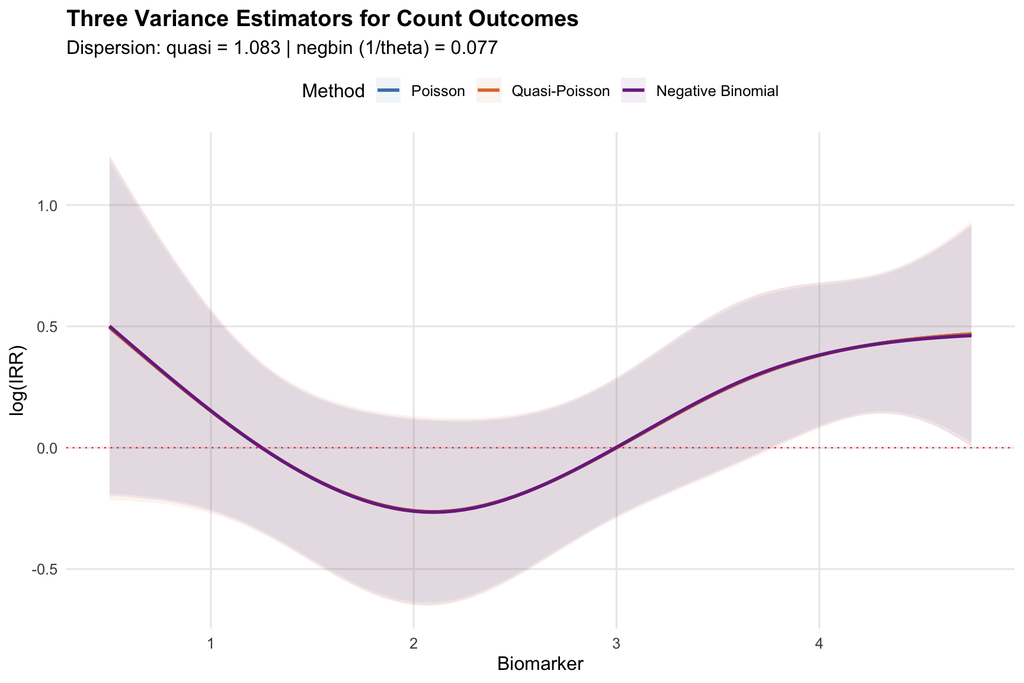

All three variance estimators. Point estimates are nearly identical; CIs widen with stronger overdispersion correction.

```r
df_all <- rbind(
  data.frame(biomarker = prof_pois$z_profile, est = prof_pois$est,
             lower = prof_pois$lower, upper = prof_pois$upper,
             Method = "Poisson"),
  data.frame(biomarker = prof_quasi$z_profile, est = prof_quasi$est,
             lower = prof_quasi$lower, upper = prof_quasi$upper,
             Method = "Quasi-Poisson"),
  data.frame(biomarker = prof_nb$z_profile, est = prof_nb$est,
             lower = prof_nb$lower, upper = prof_nb$upper,
             Method = "Negative Binomial")
)
df_all$Method <- factor(df_all$Method,
                         levels = c("Poisson", "Quasi-Poisson",
                                    "Negative Binomial"))

ggplot(df_all, aes(x = biomarker, y = est, colour = Method, fill = Method)) +
  geom_ribbon(aes(ymin = lower, ymax = upper), alpha = 0.08, colour = NA) +
  geom_line(linewidth = 1.0) +
  geom_hline(yintercept = 0, linetype = "dotted", color = "red", linewidth = 0.4) +
  scale_colour_manual(values = c("Poisson" = "steelblue",
                                  "Quasi-Poisson" = "#E07B39",
                                  "Negative Binomial" = "#7B2D8E")) +
  scale_fill_manual(values = c("Poisson" = "steelblue",
                                "Quasi-Poisson" = "#E07B39",
                                "Negative Binomial" = "#7B2D8E")) +
  labs(x = "Biomarker", y = "log(IRR)",
       title = "Three Variance Estimators for Count Outcomes",
       subtitle = sprintf(
         "Dispersion: quasi = %.3f | negbin (1/theta) = %.3f",
         prof_quasi$dispersion, prof_nb$dispersion
       )) +
  theme_minimal(base_size = 12) +
  theme(legend.position = "top", panel.grid.minor = element_blank(),
        plot.title = element_text(face = "bold"))
```

# 8 GRF Transform Comparison

The `grf_count_transform` parameter controls how the count outcome is transformed before passing to `grf::causal_forest()` for factor screening.

```r
grf_identity <- grf.subg.harm.glm(
  data                = df,
  confounders.name    = c("v1", "v2", "v3", "age"),
  outcome.name        = "events",
  treat.name          = "treat",
  id.name             = "id",
  outcome_type        = "count",
  effect_measure      = "log_IRR",
  offset.name         = "person_time",
  overdispersion      = "none",
  grf_count_transform = "identity",
  n.min               = 60,
  seedit              = 8316951,
  verbose             = TRUE
)
```

```r
vi_log <- sort(grf_pois$grf_varimp, decreasing = TRUE)
vi_id  <- sort(grf_identity$grf_varimp, decreasing = TRUE)

vi_df <- data.frame(
  Variable = names(vi_log),
  `Importance (log)` = as.numeric(vi_log),
  `Importance (identity)` = as.numeric(vi_id[names(vi_log)]),
  check.names = FALSE
)

gt(vi_df) |>
  tab_header(
    title = "GRF Variable Importance by Transform",
    subtitle = sprintf("log(Y + 0.5) vs raw Y | n = %d | %d zero counts",
                        n, sum(df$events == 0))
  ) |>
  fmt_number(columns = c("Importance (log)", "Importance (identity)"),
             decimals = 4) |>
  tab_source_note(
    sprintf("log SG: %s | identity SG: %s",
            paste(grf_pois$sg.harm.id, collapse = " & "),
            paste(grf_identity$sg.harm.id, collapse = " & "))
  )
```

GRF screening: log vs identity transform

GRF Variable Importance by Transform

log(Y + 0.5) vs raw Y | n = 800 | 462 zero counts

| Variable | Importance (log) | Importance (identity) |
| --- | --- | --- |
| age | 0.4201 | 0.3991 |
| v1 | 0.4125 | 0.4488 |
| v2 | 0.0897 | 0.0739 |
| v3 | 0.0777 | 0.0781 |

log SG: v2 <= 1 & v1 <= 1 & age <= 53 | identity SG: v1 <= 1 & age <= 88 & age <= 30

# 9 Timing Summary

```r
timings$total <- (proc.time() - t_vignette_start)["elapsed"]

timing_df <- data.frame(
  Stage = c("GRF (Poisson)", "GRF (quasi-Poisson)",
            "Effect profile (Poisson)", "Total"),
  Seconds = c(
    timings$grf_poisson, timings$grf_quasi,
    timings$profile_poisson, timings$total
  ),
  stringsAsFactors = FALSE
)

gt(timing_df) |>
  tab_header(title = "Computational Timing") |>
  fmt_number(columns = Seconds, decimals = 1) |>
  cols_label(Stage = "Stage", Seconds = "Time (sec)") |>
  tab_style(
    style = cell_text(weight = "bold"),
    locations = cells_body(rows = Stage == "Total")
  )
```

Computational Timing

| Stage | Time (sec) |
| --- | --- |
| GRF (Poisson) | 0.1 |
| GRF (quasi-Poisson) | 0.2 |
| Effect profile (Poisson) | 0.0 |
| Total | 0.9 |

# 10 Summary

This document exercised the three new count-data functions in ForestSearch v0.2.0: